# Tracking COVID Cases in Relation to Country Freedom

Over the Course of the COVID-19 Pandemic

# Introduction

In this project, we examined the relationship between the stringency of a country’s COVID policy, i.e. the relative freedom allowed the people of the country during the COVID pandemic, and the per capita number of COVID cases that occurred in that country. We also observed how the levels of freedom and corresponding COVID case numbers changed over the three year course of the pandemic for which we have data, i.e. how responses shifted from the 2020 beginnings of the pandemic, to 2021, and up to 2022. To do so, we clustered countries by total number of deaths, total number of cases, and overall happiness score, and, based on these groupings at the start of the pandemic (2020 data) chose a country to examine. Additional countries were selected to ensure that nearly all continents (barring Antarctica, Australia, and North America) were included. For a country to be considered for further examination, they had to have data for all three years (no North American Country met this requirement, and thus was excluded) and had to have readily available text resources on their COVID policy. Otherwise, countries were chosen at random in an attempt to encompass a broader range of country experiences. We then performed text analysis on the COVID policies of these chosen countries to identify the most commonly used words in their COVID policies, to examine what regulations were present, and how this might have effected their per capita rate of COVID 19 infection within their country.

# Freedom According to the World Happiness Report vs COVID Cases (Scatterplot)

In the SHINY App portion of our project, we observed (see below) that there appeared to be a relationship where in countries with a higher number of COVID cases appeared to correspond to countries that scored higher on the World Happiness Report in the “Freedom to Make Life Decisions” category. This effect was most pronounced in 2022 (a number of years into the pandemic, indeed the latest year we studied) where the number of cases appeared to increase above levels of 2020 and 2021, particularly in countries with higher “Freedom to Make Life Decision” scores. It occurred to us that in the early year of the pandemic, even countries that typically scored high on the “Freedom to Make Life Decisions” indicators of the World Happiness Report when faced with a never-before-seen threat to their people, may have responded more strictly to the unknown that was the pandemic. However, as time went on, we wondered if perhaps the COVID regulations imposed by various governments were swayed by their more typical “freedom leanings” as measured by the World Happiness Report, and that countries with more “Freedom the Make Life Decisions” relaxed their COVID mandates more quickly, leading to surges in COVID cases during the later years of the pandemic (particularly 2022). This lead us to the desire to look at “Freedom to Make Life Decision Scores” within each country over the course of the pandemic to see if they took into account COVID policy and how they might have changed during the pandemic.

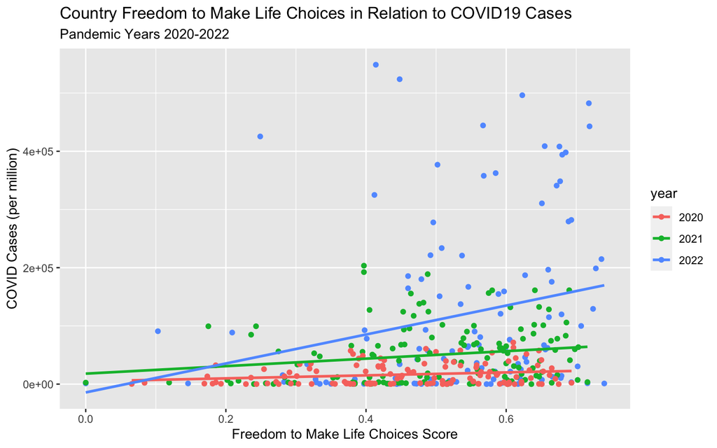

# Freedom of Countries Accross the World According to the World Happiness Report (Maps)

We first looked at a map of world “Freedom to Make Life Decision” scores in 2019, while COVID-19 was still mainly sequestered in mainland China and not the rest of the country, so that we could examine what various country freedoms looked like prior to the pandemic and compare them to pandemic levels to see how well the Happiness Report measure of “Freedom to Make Life Decisions” captured/accounted for changes in policy based on COVID 19.

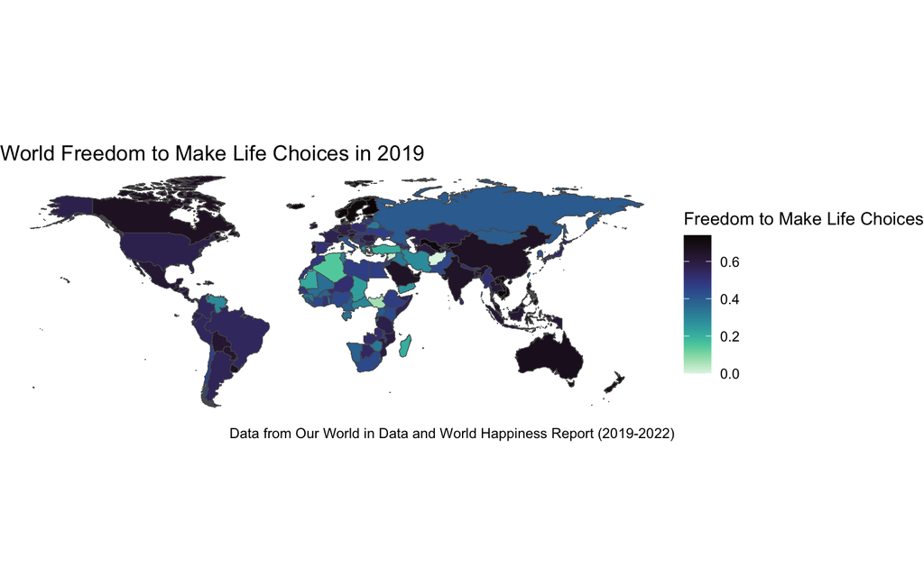

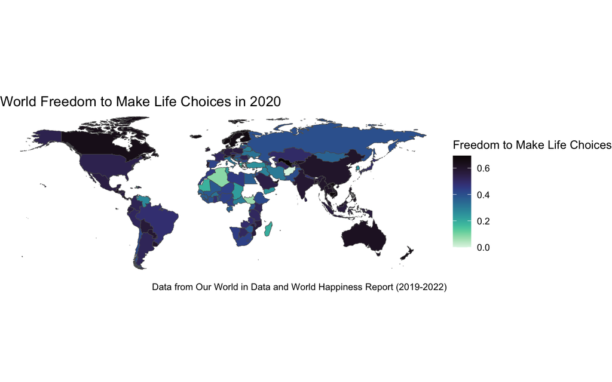

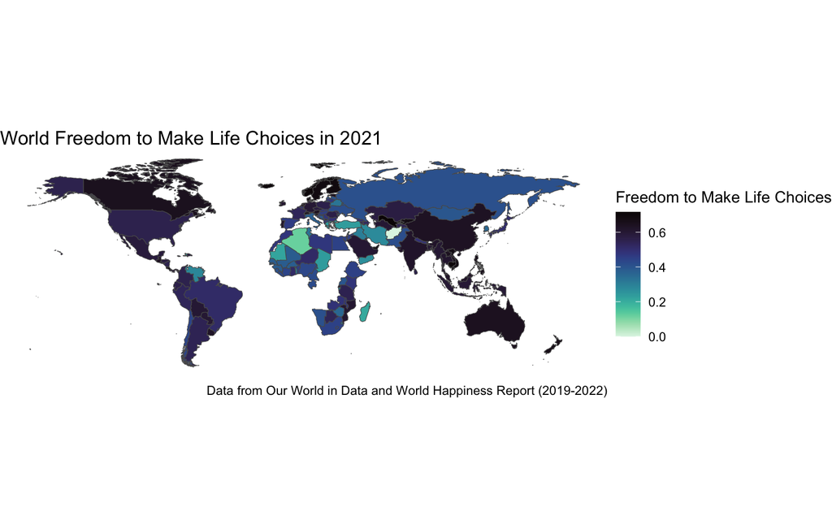

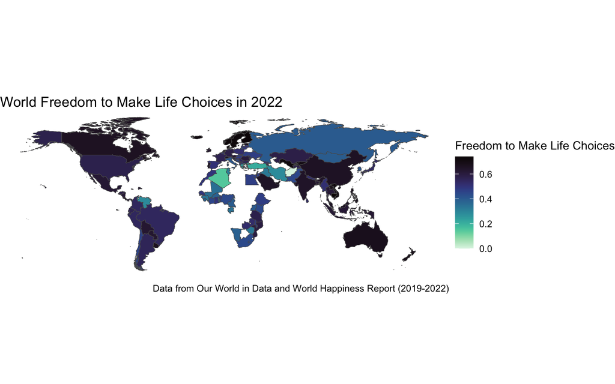

Across the studied years, both when comparing prior to pandemic levels and levels between years in the pandemic, there appeared to be no great differences between the “Freedom to Make Life Decision” score based on the year, suggesting that the World Happiness Report survey perhaps did not measure or account for the changes in the freedom of everyday lives of citizens based on the pandemic, or that freedom levels simply did not change that much over the course of the pandemic, particularly in country relations to one another, though we found this second argument less convincing given personal experiences of the pandemic, and how the freedom of our lives changes (though perhaps our outlooks were shaped by the tight Amherst College restrictions). We decided to investigated country freedom vs. COVID cases using other possible measures: directly through text analysis of the regulations they imposed. First though, we had to decide on representative countries to examine.

# Freedom and COVID Cases (Clustering)

To pick representative countries to explore, we wanted to cluster countries by their number of COVID cases per million people, their Freedom to Make Life Decisions score, but also, from our original dataset, their Happiness Score and COVID deaths per million people so that our clusters more accurately reflect countries we expect to have had more similar outlooks on life, and in particular, on COVID 19 regulations. All measurements were standardized so that they would be weighted equally. We began this process with the year 2020 – the start of the pandemic. We decided on creating four clusters as creation of an elbow plot (see below) suggested we should.

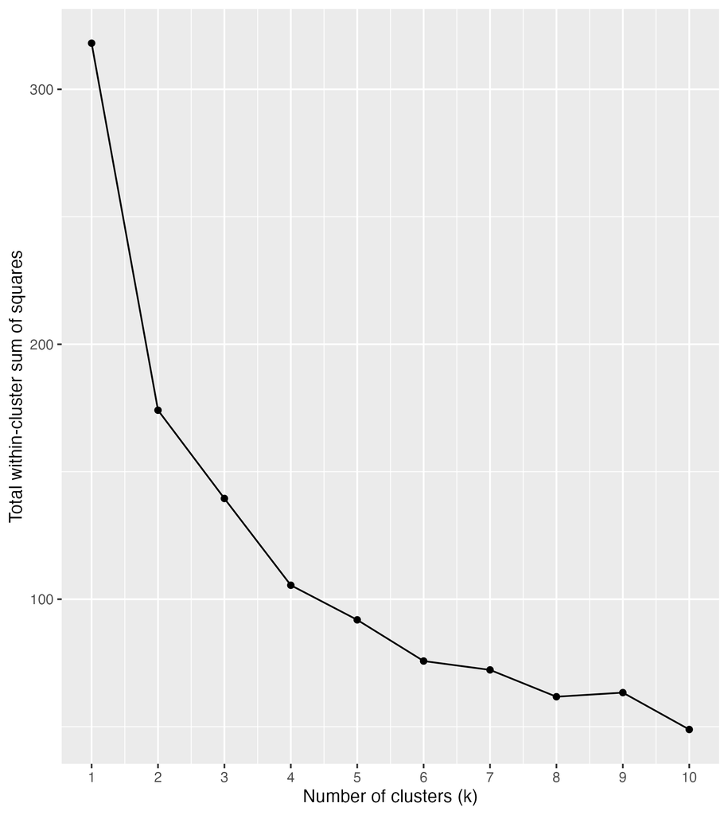

2020 Clustering of COVID Cases vs Country Freedom Score

The clusters for 2020, on a plot of COVID Cases vs Freedom to Make Life Decisions score are depicted below.

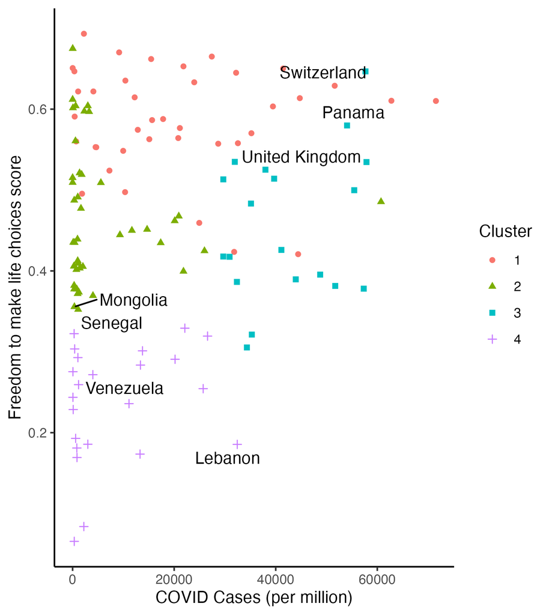

2020 Clustering of COVID Cases vs Country Freedom Score

In addition to taking in 2020 clusters to track over time and to track their explicit regulations, we also attempted to chose countries from as many continents as possible in an attempt to get a broader view of global responses. We were also limited in our selection by the quality of the resources we could find to mine for text data on their regulations and policies. We intentionally also chose a mix of country sizes in, again, and attempt to get a sense of what COVID was like in as wide a range of experiences as possible to get a better global picture.

In the end, we chose to study the countries Lebanon and Mongolia (Asia), Venezuela and Panama (South America), Senegal (Africa), as well as the United Kingdom and Switzerland (Europe). These are labeled with text on the plot above.

Below is a plot of the 2021 COVID Cases vs Freedom to Make Life Choices/Decisions scores, clustered based on the same criteria as that of the 2020 clustering.

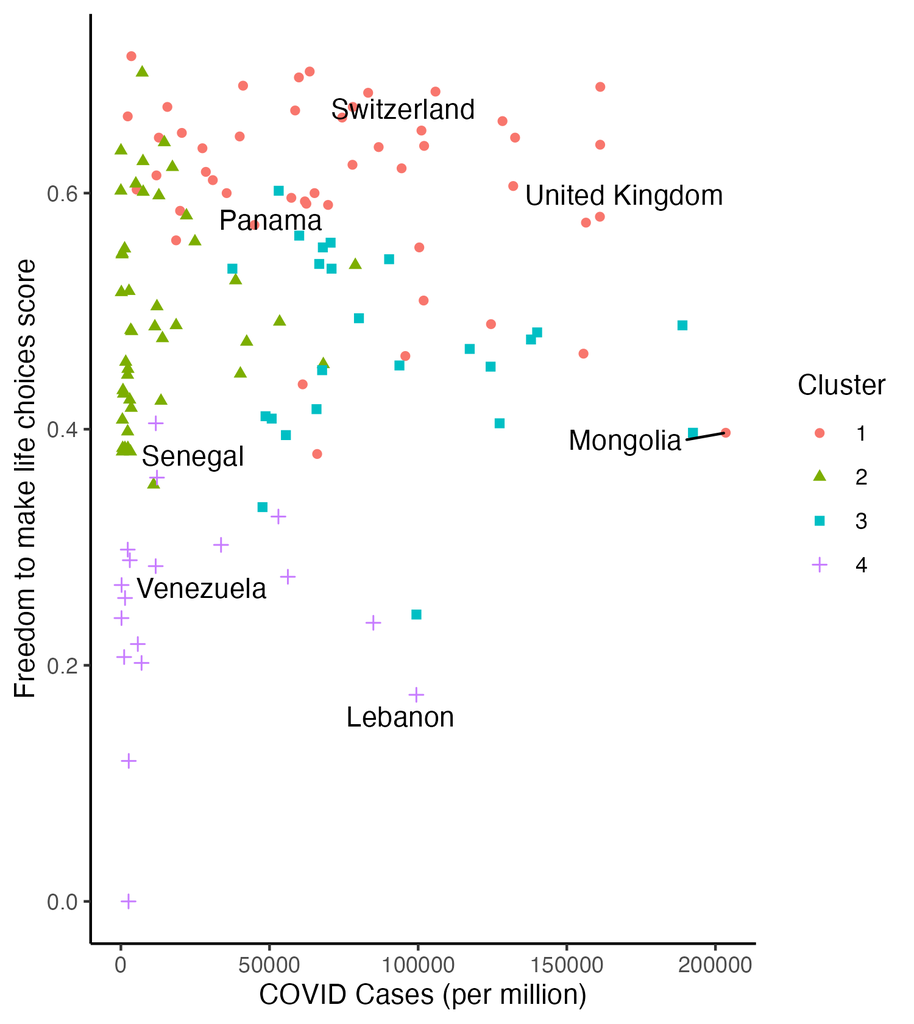

2021 Clustering of COVID Cases vs Country Freedom Score

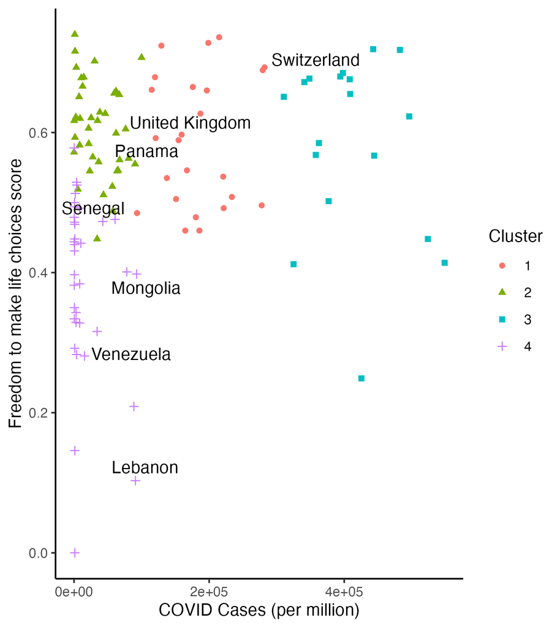

2022 Clustering of COVID Cases vs Country Freedom Score